# Pemodelan ARIMA - Pendugaan Parameter, Diagnostik Model, dan Peramalan

Author

Tasya Revadea

Published

September 24, 2026

## 1 Packages

```r
library(ggplot2)
library(tsibble)
library(tseries)
library(MASS)
library(forecast)
library(TSA)
library(TTR)
library(aTSA)
library(graphics)
library(lmtest)
library(car)
library(readxl)
```

## 2 Impor Data

Data berisi kelembapan udara (%) yang diukur setiap jam. Variabel Period adalah urutan waktu dan Humidity adalah nilai kelembapan.

```r
df <- read_excel("data kelembapan (per jam).xlsx")
str(df)
```

```
tibble [548 × 2] (S3: tbl_df/tbl/data.frame)
 $ Period  : num [1:548] 1 2 3 4 5 6 7 8 9 10 ...
 $ Humidity: num [1:548] 93 87 87 84 78 76 71 66 62 58 ...
```

```r
n <- nrow(df)
df.ts <- ts(df$Humidity)
```

```r
ntrain <- floor(0.8 * n)
train  <- df$Humidity[1:ntrain]
test   <- df$Humidity[(ntrain + 1):n]
df.train <- ts(train)
df.test  <- ts(test, start = ntrain + 1)
c(n_latih = length(train), n_uji = length(test))
```

```
n_latih   n_uji
    438     110
```

## 3 Plot Data

Sebelum masuk dalam tahap pemodelan, dilakukan eksplorasi data dengan plot deret waktu untuk melihat pola data.

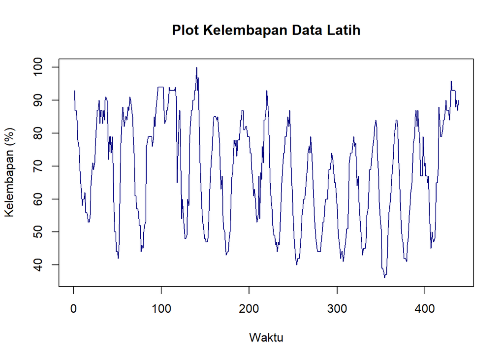

```r
#--PLOT TIME SERIES--#
plot(df.train, lty = 1, col = "navyblue", xlab = "Waktu", ylab = "Kelembapan (%)", main = "Plot Kelembapan Data Latih")
```

Data latih bergerak di sekitar nilai tengah tertentu tanpa tren yang jelas, dan lebar pita fluktuasinya relatif konstan. Secara visual data cenderung stasioner dalam rataan dan ragam.

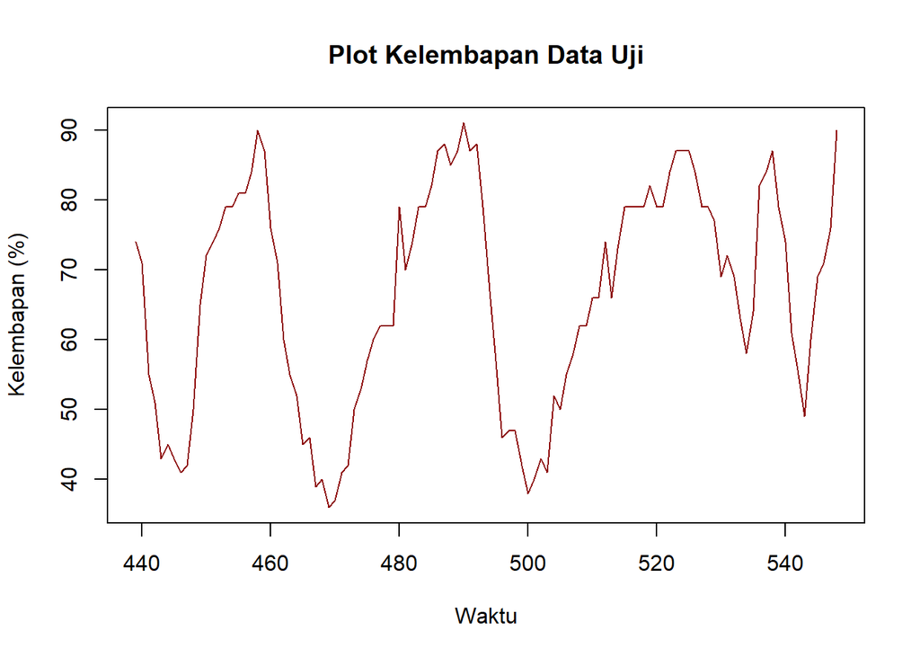

```r
plot.ts(df.test, lty = 1, col = "darkred", xlab = "Waktu", ylab = "Kelembapan (%)", main = "Plot Kelembapan Data Uji")
```

## 4 Uji Stasioneritas

### 4.1 Plot ACF

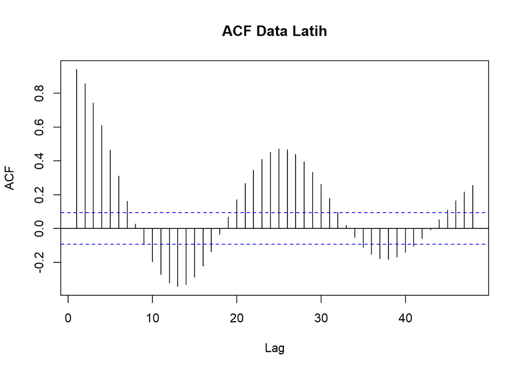

```r
acf(df.train, main = "ACF Data Latih", lag.max = 48)
```

Plot ACF turun secara perlahan (tails off slowly) dan berbentuk gelombang yang berulang sekitar setiap 24 lag (korelasi positif kuat di lag 24, negatif di sekitar lag 12). Ini adalah ciri data jam-an dengan pola harian. Penurunan yang lambat sering menjadi tanda ketidakstasioneran dalam rataan, tetapi pada data ini perlu dikonfirmasi dengan uji formal.

## 5 Uji ADF

```r
tseries::adf.test(df.train)
```

```
    Augmented Dickey-Fuller Test

data:  df.train
Dickey-Fuller = -6.874, Lag order = 7, p-value = 0.01
alternative hypothesis: stationary
```

$H_0$ : Data tidak stasioner dalam rataan

$H_1$ : Data stasioner dalam rataan

Berdasarkan uji ADF tersebut, didapat *p-value* sebesar 0.01 yang lebih kecil dari taraf nyata 5% sehingga tolak $H_0$ dan menandakan bahwa data stasioner dalam rataan. Hal ini sesuai dengan hasil eksplorasi menggunakan plot time series dan plot ACF.

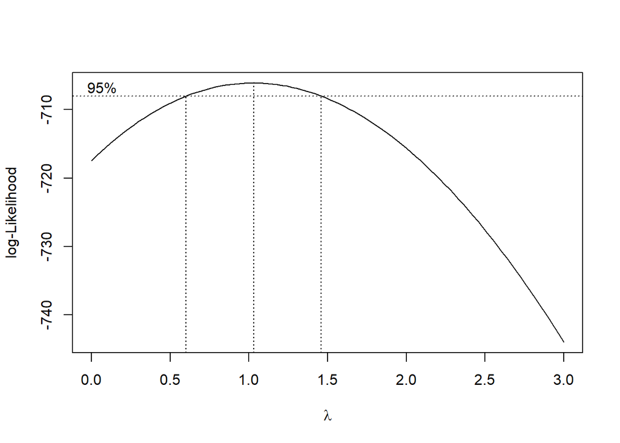

```r
index <- seq(1:length(df.train))
bc <- boxcox(df.train ~ index, lambda = seq(0, 3, by = 0.1))
```

```r
lambda_opt <- bc$x[which.max(bc$y)]
lambda_opt
```

```
[1] 1.030303
```

```r
ci_lambda <- bc$x[bc$y > max(bc$y) - 0.5 * qchisq(0.95, df = 1)]
c(Batas_Bawah = min(ci_lambda), Batas_Atas = max(ci_lambda))
```

```
Batas_Bawah  Batas_Atas
  0.6060606   1.4545455
```

Nilai $\lambda$ optimum adalah 1.030303, dengan selang kepercayaan 95% dari 0.6060606 sampai 1.4545455. Selang tersebut memuat nilai 1 sehingga tidak diperlukan transformasi, atau data sudah stasioner dalam ragam.

## 6 Identifikasi Model

Karena data sudah stasioner, orde pembeda (d = 0) sehingga model yang dicari adalah ARMA(p, q) atau ARIMA(p, 0, q).

### 6.1 Plot ACF dan PACF

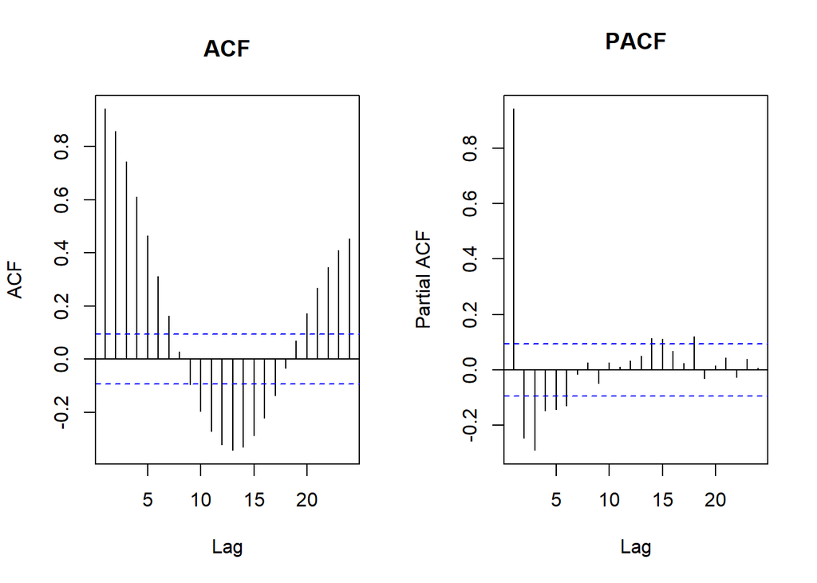

```r
par(mfrow = c(1, 2))
acf(df.train,  main = "ACF",  lag.max = 24)
pacf(df.train, main = "PACF", lag.max = 24)
```

ACF turun perlahan (tails off) sedangkan PACF terpotong (cuts off) setelah beberapa lag awal (lag 1 sangat besar, lag 2 dan 3 masih signifikan). Pola ini mengarah ke model AR, dengan kandidat ARIMA(1,0,0), ARIMA(2,0,0), dan ARIMA(3,0,0).

### 6.2 Plot EACF

```r
eacf(df.train)
```

```
AR/MA
  0 1 2 3 4 5 6 7 8 9 10 11 12 13
0 x x x x x x x o o x x  x  x  x
1 x x x x x x x o x x x  x  x  x
2 x x o o o o o o o o o  o  o  o
3 x x o o o o o o o o o  o  o  o
4 x o x o o o o o o o o  o  o  o
5 x o x o o o o o o o o  o  o  o
6 o x x o x o o o o o o  o  o  o
7 x o x o x o o o o o o  o  o  o
```